# Fish Microplastics

Ashlee Pilon & Maison Erridge

2026-03-10

```r
library(tidyverse)
library(janitor)
library(naniar)
library(ggmap)
library(lubridate)
library(shiny)
library(dplyr)
library(shinydashboard)
library(ggplot2)
library(readr)
```

**download the data* (A)**

```r
microplastics <- read.csv("microplastics.csv")
```

**Clean names (A)**

```r
microplastics <- microplastics %>%
  clean_names()
```

**Check NAs (A)**

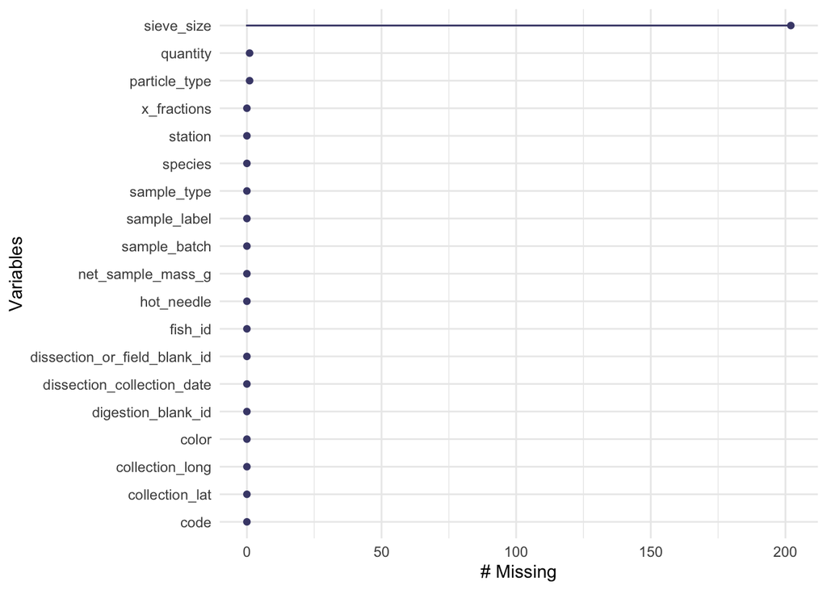

```r
microplastics  %>%
  gg_miss_var()
```

**Make a map of the locations where fish were collected from.(A)**

```r
register_stadiamaps("280bdc76-265c-4420-af16-f3fc7ab98211", write = FALSE)
```

```r
microplastics %>%
  select(collection_lat, collection_long) %>%
  summary()
```

```
##  collection_lat  collection_long
##  Min.   :27.32   Min.   :-82.65
##  1st Qu.:27.32   1st Qu.:-82.65
##  Median :27.42   Median :-82.65
##  Mean   :27.37   Mean   :-82.60
##  3rd Qu.:27.42   3rd Qu.:-82.55
##  Max.   :27.42   Max.   :-82.55
```

```r
lat <- c(27, 27.75)
long <- c(-83, -82)
bbox <- make_bbox(long, lat, f= 0.03)
unique(microplastics$collection_long)
```

```
## [1] -82.64988 -82.54724
```

```r
map_fish <- get_stadiamap(bbox, maptype = "stamen_terrain", zoom = 7)
```

```
## ℹ © Stadia Maps © Stamen Design © OpenMapTiles © OpenStreetMap contributors.
```

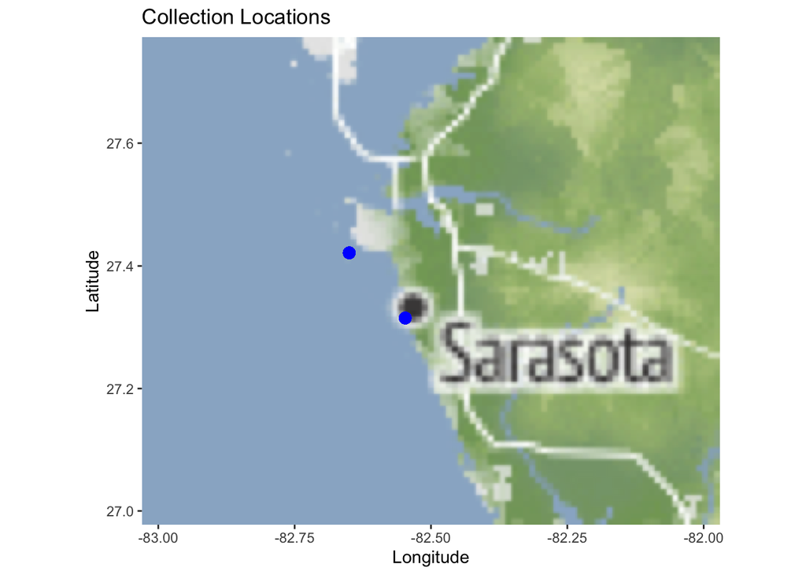

```r
ggmap(map_fish) +
  geom_point(data = microplastics, aes(collection_long, collection_lat), size = 3, color = "blue" , alpha = 0.8)+
  labs(x = "Longitude", y = "Latitude", title = "Collection Locations")
```

```r
microplastics <- microplastics %>%
  mutate(station = case_when(
    collection_long == -82.64988 ~ "Station 1",
    collection_long == -82.54724 ~ "Station 2"
  ))
```

**Mutate the fish_id column to create a new column called species that has the full name of the species of fish collected. The first two letters of the fish_id correspond to the species of fish collected. (A)**

```r
microplastics <- microplastics %>%
  mutate(code = substr(fish_id, 1, 2),
         species = case_when(
           code == "Oc" ~ "orthopristis chrysoptera",
           code == "OC" ~ "orthopristis chrysoptera",
           code == "Lr" ~ "lagodon rhomboides",
           code == "Af" ~ "ariopsis felis",
           code == "Ob" ~ "opsanus beta"
         ))
```

**make the blank box in particle_type into NA (A)**

```r
microplastics <- microplastics %>%
  mutate(particle_type = na_if(particle_type, ""))
```

**Save our edited data frame as a new csv file (A)**

```r
#write_csv(microplastics, "microplastics.csv"))
```

**Build shiny app (A)**

```r
ui <- dashboardPage(

  skin = "purple",

  dashboardHeader(title = "Fish Microplastics"),

  dashboardSidebar(

    selectInput("z",
                "Select a variable of interest",
                choices = c("color", "particle_type", "sample_type", "species"),
                selected = "color"),

    selectInput("x",
                "Select a variable of interest",
                choices = c("station", "species"),
                selected = "station")
  ),

  dashboardBody(

    plotOutput("plot", width = "500px", height = "400px")

  )
)

server <- function(input, output, session) {

  output$plot <- renderPlot({

    microplastics %>%
      ggplot(aes(x = .data[[input$x]], fill = .data[[input$z]])) +
      geom_bar(position = "dodge") +
      theme_bw() +
      labs(x = input$x, fill = input$z)

  })
}

shinyApp(ui, server)
```

**bar plot for count by station**

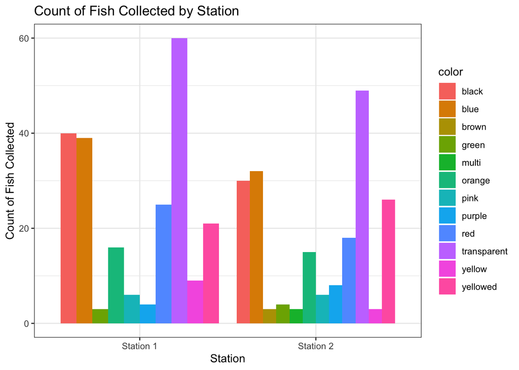

```r
microplastics %>%
  ggplot(aes(x= station, fill = color)) +
  geom_bar(position = "dodge") +
  theme_bw() +
  labs(x = "Station", y = "Count of Fish Collected", title = "Count of Fish Collected by Station")
```

**Boxplot of sample mass by species (A)**

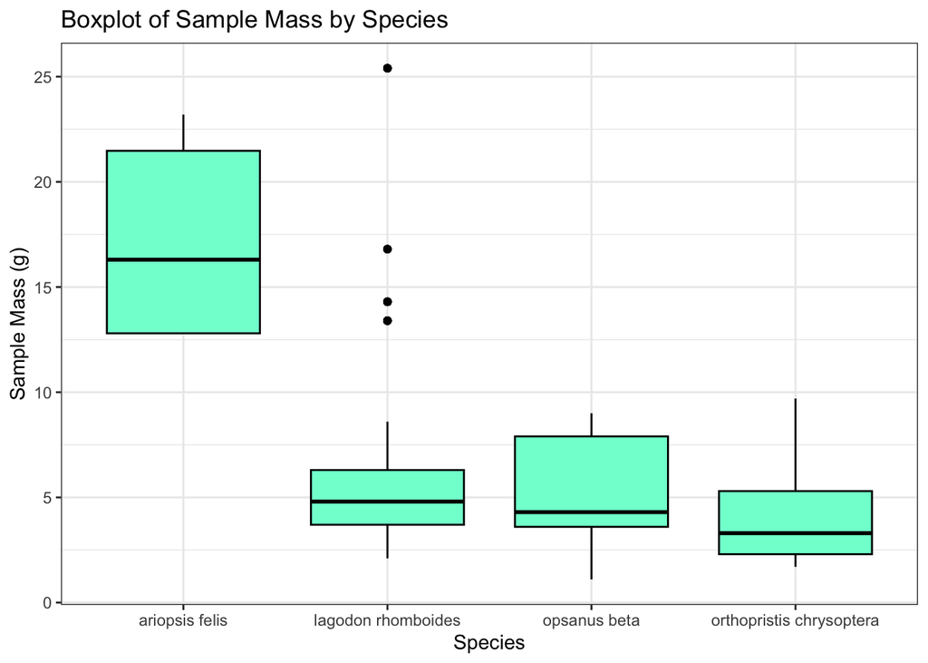

```r
microplastics %>%
  ggplot(aes(x= species, y = net_sample_mass_g)) +
  geom_boxplot(fill = "aquamarine", color = "black") +
  theme_bw() +
  labs(x = "Species", y = "Sample Mass (g)", title = "Boxplot of Sample Mass by Species")
```

**Boxplot of sample mass by station (A)**

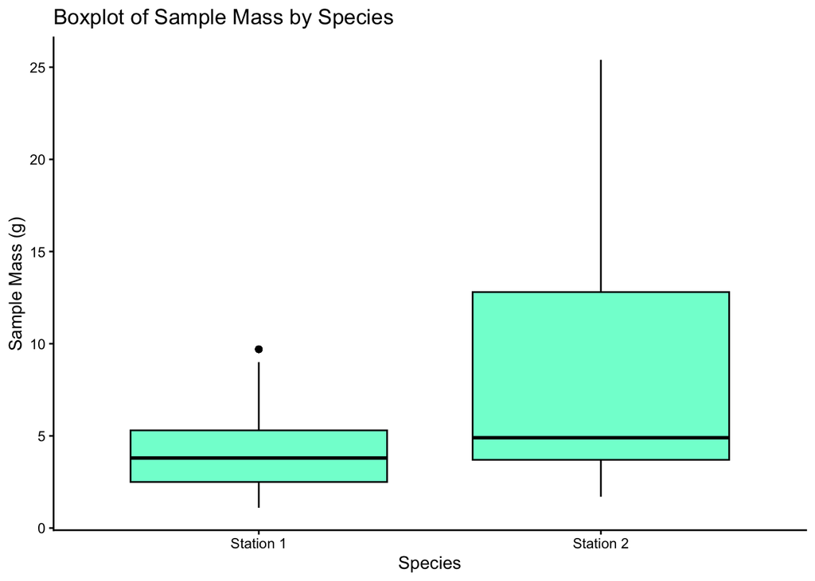

```r
microplastics %>%
  ggplot(aes(x= station, y = net_sample_mass_g)) +
  geom_boxplot(fill = "aquamarine", color = "black") +
  theme_classic() +
  labs(x = "Species", y = "Sample Mass (g)", title = "Boxplot of Sample Mass by Species")
```

**box plot of weights of each particle type (A)**

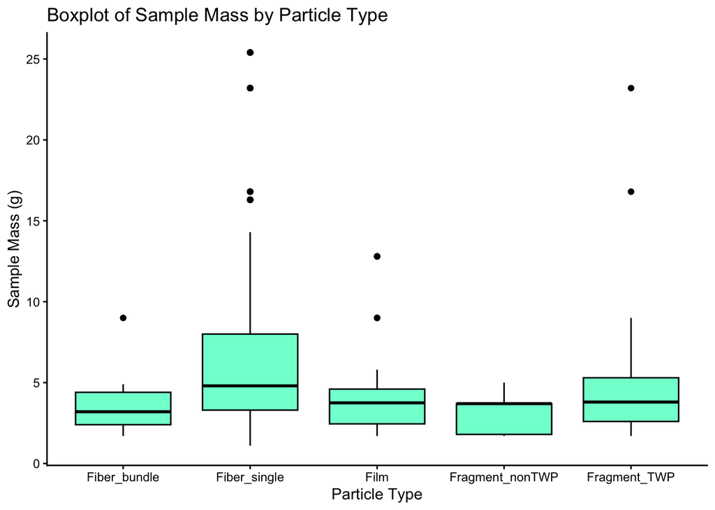

```r
microplastics %>%
  filter(!is.na(particle_type)) %>%
  ggplot(aes(x= particle_type, y = net_sample_mass_g)) +
  geom_boxplot(fill = "aquamarine", color = "black") +
  theme_classic() +
  labs(x = "Particle Type", y = "Sample Mass (g)", title = "Boxplot of Sample Mass by Particle Type")
```

**Particles taken from each sample type by species (M)**

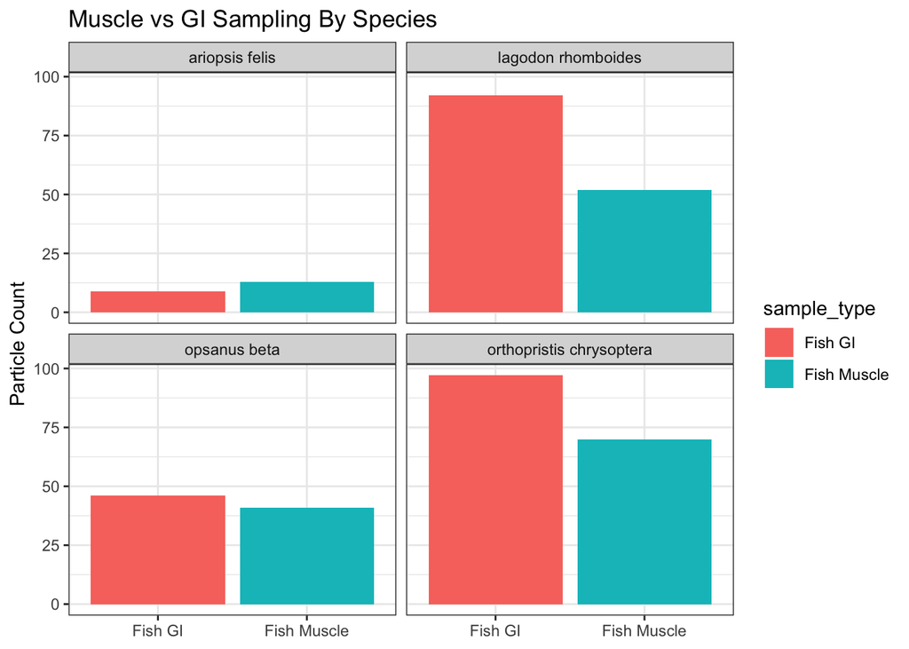

```r
microplastics %>%
  ggplot(aes(x = sample_type, fill= sample_type)) +
  geom_bar() +
  theme_bw()+
  facet_wrap(~ species)+
  labs(title = "Muscle vs GI Sampling By Species", x = NULL, y = "Particle Count")
```

**Particle Types by Species (M)**

[output not shown]

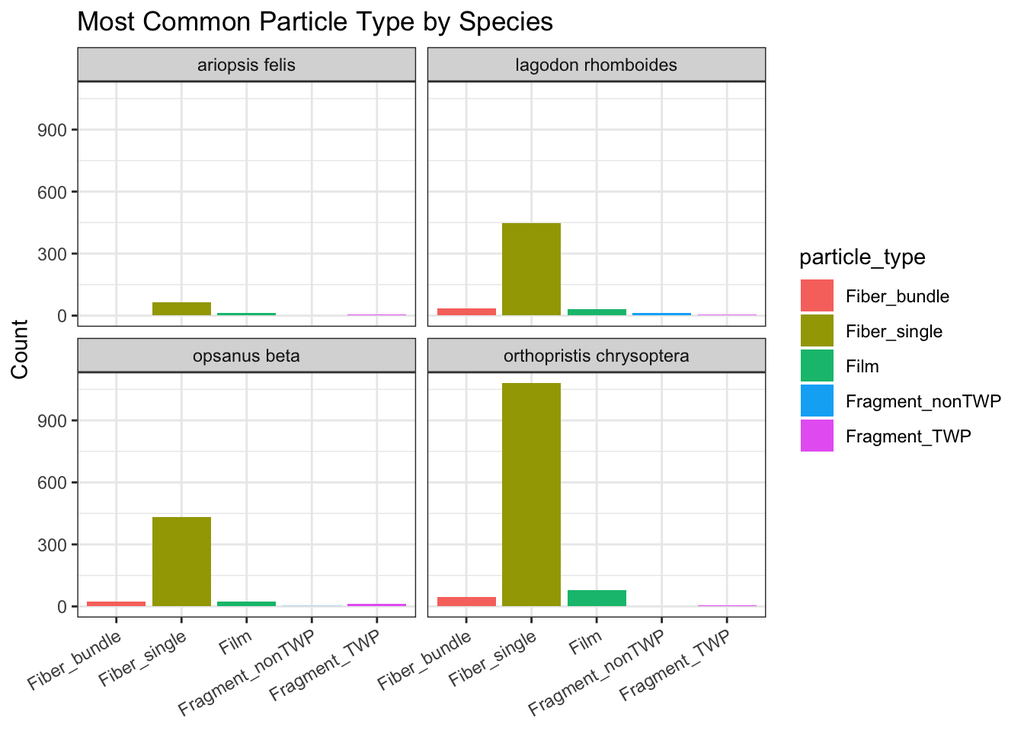

```r
microplastics %>%
  group_by(species, particle_type) %>%
  summarise(total = sum(quantity)) %>%
  filter(!is.na(particle_type)) %>%
  ggplot(aes(x = particle_type, y = total, fill = particle_type)) +
  geom_col() +
  facet_wrap(~ species) +
  labs(title = "Most Common Particle Type by Species", x = NULL, y = "Count") +
  theme_bw() +
  theme(axis.text.x = element_text(angle = 30, hjust = 1))
```

**Everything was confirmed plastic (M)**

[output not shown]

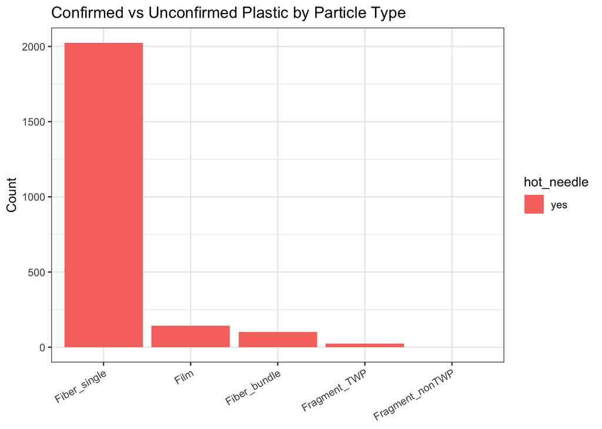

```r
microplastics %>%
  filter(!is.na(hot_needle), !is.na(particle_type)) %>%
  group_by(particle_type, hot_needle) %>%
  summarise(total = sum(quantity)) %>%
  ggplot(aes(x = reorder(particle_type, -total), y = total, fill = hot_needle)) +
  geom_col(position = "stack") +
  labs(title = "Confirmed vs Unconfirmed Plastic by Particle Type", x = NULL, y = "Count") +
  theme_bw() +
  theme(axis.text.x = element_text(angle = 30, hjust = 1))
```

**Where plastic was found for each species in each sample (M)**

[output not shown]

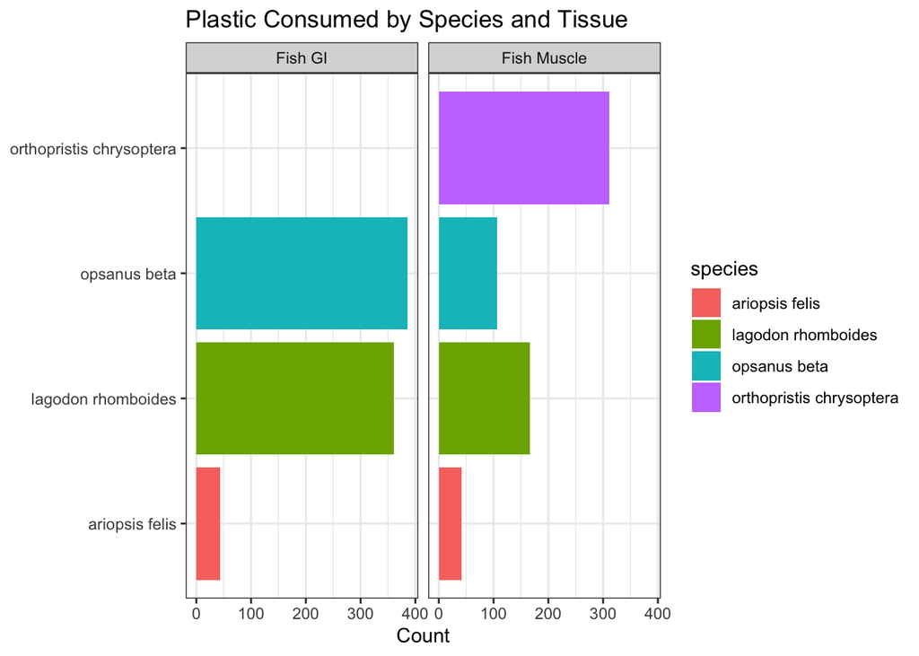

```r
microplastics %>%
  group_by(species, sample_type) %>%
  summarise(total = sum(quantity)) %>%
  filter(!is.na(sample_type)) %>%
  ggplot(aes(x = species, y = total, fill = species)) +
  geom_col() +
  facet_wrap(~ sample_type) +
  coord_flip() +
  labs(title = "Plastic Consumed by Species and Tissue", x = NULL, y = "Count") +
  theme_bw()
```

**Percentage of fihs with TWP by species (M)**

[output not shown]

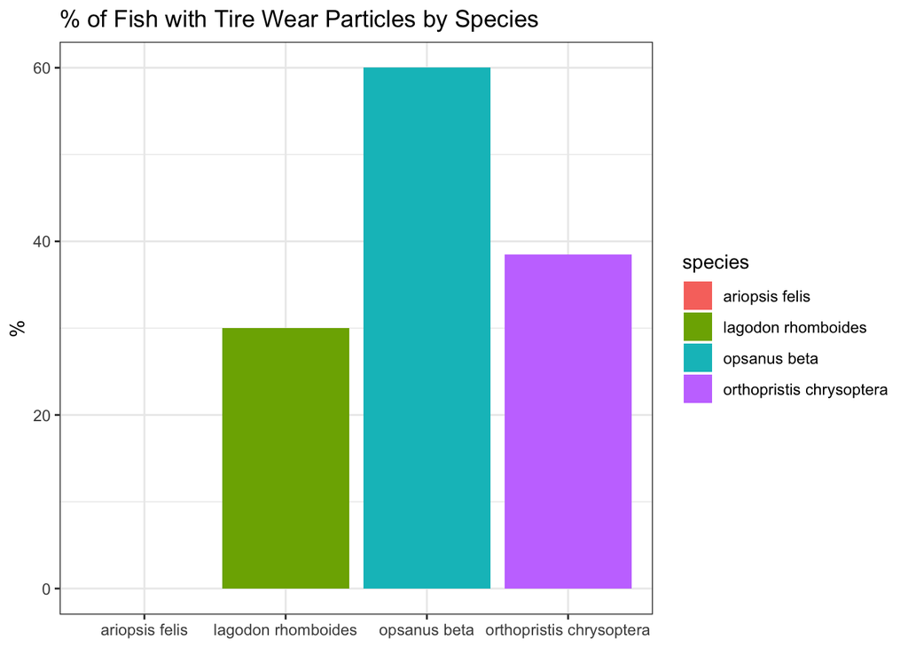

```r
microplastics %>%
  group_by(fish_id, species) %>%
  summarise(has_twp = any(particle_type == "Fragment_TWP")) %>%
  group_by(species) %>%
  summarise(pct = mean(has_twp) * 100) %>%
  ggplot(aes(x = species, y = pct, fill = species)) +
  geom_col() +
  labs(title = "% of Fish with Tire Wear Particles by Species", x = NULL, y = "%") +
  theme_bw()
```

13. - Made/organized the presentation
14. - organized the repository/exploratory analysis